# issp 99-09-19

viernes 28 julio 2023 17:02:32

# 1 Cargar paquetes

```r
knitr::opts_chunk$set(warning = FALSE,
                      message = FALSE,
                      cache = FALSE,
                      results = "hold")
options(scipen=999)
if (!require("pacman")) install.packages("pacman") # instalar pacman
```

```r
pacman::p_load(dplyr, haven, stargazer, sjmisc, sjPlot, sjlabelled, tidyverse, summarytools)
```

# 2 cargar base de datos issp 1999

```r
data_1999 <- read_sav("input/original/ISSP1999.sav")

chile_1999 <- data_1999 %>% filter(V3==30) %>% select(WEIGHT,
                                                      educacion=DEGREE,
                                                      sex=SEX,
                                                      age=AGE,
                                                      region=X_REG,
                                                      V15, #doctor
                                                      V16, #gerente
                                                      V18, #asistente tienda,
                                                      V21, #obrero no calificado
                                                      V22, #Ministro gob
                                                      V25, #Doctor
                                                      V26, #gerente
                                                      V28, #asistente tienda
                                                      V31, #obrero no calificado
                                                      V32 #Ministro gob
                                                     )

summary(chile_1999$V16) # original
summary(chile_1999$V21)
```

```
##        Min.     1st Qu.      Median        Mean     3rd Qu.        Max.
##      100000     2000000    10000000 37995788975 99999999998 99999999999
##        Min.     1st Qu.      Median        Mean     3rd Qu.        Max.
##       10000       90000      100000 20293168113      160000 99999999999
```

### 2.0.1 eliminar NA (9999999999) y (99)

```r
chile_1999 <- chile_1999 %>% set_na(., na = c(99999999999, 99999999998), drop.levels = FALSE, as.tag = FALSE) %>% as.data.frame()
summary(chile_1999$V21)

chile_1999 <- set_label(chile_1999, c("WEIGHT", "Educacion", "Sexo", "Edad", "Region", "Percibido: Doctor", "Percibido: Gerente", "Percibido: Asistente de tienda", "Percibido: Obrero", "Percibido: Ministro de Gobierno", "Justo: Doctor", "Justo: Gerente", "Justo: Asistente de tienda", "Justo: Obrero", "Justo: Ministro de Gobierno"))
```

```
##      Min.   1st Qu.    Median      Mean   3rd Qu.      Max.      NA's
##     10000     90000     90000    527274    100000 120000000       305
```

- Educacion

```r
table(chile_1999$educacion)

chile_1999 <- chile_1999 %>% rowwise() %>%  mutate(educacion_rec = case_when(educacion==1~"Educación media incompleta",
                                                 educacion==2~"Educación media incompleta",
                                                 educacion==3~"Educación media incompleta",
                                                 educacion==4~"Educación media incompleta",
                                                 educacion==5~"Educación media completa",
                                                 educacion==6~"Educación media completa",
                                                 educacion==7~"Educación universitaria"
                                                 ))

chile_1999$educacion_rec <- factor(chile_1999$educacion_rec, levels = c("Educación media incompleta", "Educación media completa", "Educación universitaria"))
```

```
##
##   1   2   3   4   5   6   7
##  39 412 179 228 387 160  81
```

- filtro de outliers según lo realizado en al artículo [“Cambios en percepción y justificación de desigualdad salarial en Chile”](https://github.com/justicia-distributiva/chile-ISSP-gaps-1999-2019/blob/master/castillo-et-al2019-analisis-del-anho.pdf)
1. Para la variable salario percibido de un obrero sacamos los valores: `<= $ 40.000 y >= $1.000.000`
2. Para la variable salario percibido de un gerente sacamos los valores: `<= $ 250.000 y >= $100.000.001`
3. Para la variable salario justo de un obrero sacamos los valores: `<= $ 40.000`
4. Para la variable salario justo de un gerente sacamos los valores: `<= $ 100.000`

```r
chile_1999 <- chile_1999 %>%
  mutate(V21_NA = sum(is.na(ifelse(V21 <= 40000 | V21>= 1000000, NA, V21))) - sum(is.na(V21))) %>%
  mutate(V21=replace(V21, V21 <= 40000 | V21>= 1000000, NA)) %>%
  mutate(V16_NA = sum(is.na(ifelse(V16 <= 250000 | V16>= 100000001, NA, V16))) - sum(is.na(V16))) %>%
  mutate(V16=replace(V16, V16 <= 250000 | V16>= 100000001, NA)) %>%
  mutate(V31_NA = sum(is.na(ifelse(V31 <= 40000, NA, V31))) - sum(is.na(V31))) %>%
  mutate(V31=replace(V31, V31 <= 40000, NA)) %>%
  mutate(V26_NA = sum(is.na(ifelse(V26 <= 100000, NA, V26))) - sum(is.na(V26))) %>%
  mutate(V26=replace(V26, V26 <= 100000, NA))
```

```r
df1 <- dfSummary(chile_1999,
               plain.ascii = FALSE,
               style = "grid",
               tmp.img.dir = "/tmp",
               graph.magnif = 0.75,
               headings = F,  # encabezado
               varnumbers = F, # num variable
               labels.col = T, # etiquetas
               na.col = T,    # missing
               graph.col = F, # plot
               valid.col = T # n valido
               )
df1$Variable <- NULL
print(df1, method = "render")
```

| **Label** | **Stats / Values** | **Freqs (% of Valid)** | **Valid** | **Missing** |
| --- | --- | --- | --- | --- |
| WEIGHT | Mean (sd) : 1 (0.2) min ≤ med ≤ max: 0.7 ≤ 0.9 ≤ 1.7 IQR (CV) : 0.4 (0.2) | 20 distinct values | 1503 (100.0%) | 0 (0.0%) |
| Educacion | Mean (sd) : 3.9 (1.6) min ≤ med ≤ max: 1 ≤ 4 ≤ 7 IQR (CV) : 3 (0.4) | 1 : 39 ( 2.6% ) 2 : 412 ( 27.7% ) 3 : 179 ( 12.0% ) 4 : 228 ( 15.3% ) 5 : 387 ( 26.0% ) 6 : 160 ( 10.8% ) 7 : 81 ( 5.5% ) | 1486 (98.9%) | 17 (1.1%) |
| Sexo | Min : 1 Mean : 1.6 Max : 2 | 1 : 657 ( 43.7% ) 2 : 846 ( 56.3% ) | 1503 (100.0%) | 0 (0.0%) |
| Edad | Mean (sd) : 44 (17.6) min ≤ med ≤ max: 18 ≤ 41 ≤ 94 IQR (CV) : 28 (0.4) | 73 distinct values | 1503 (100.0%) | 0 (0.0%) |
| Region | Mean (sd) : 3009.2 (3.7) min ≤ med ≤ max: 3001 ≤ 3009 ≤ 3013 IQR (CV) : 7 (0) | 13 distinct values | 1503 (100.0%) | 0 (0.0%) |
| Percibido: Doctor | Mean (sd) : 1116332 (1826619) min ≤ med ≤ max: 50000 ≤ 700000 ≤ 30000000 IQR (CV) : 600000 (1.6) | 50 distinct values | 1066 (70.9%) | 437 (29.1%) |
| Percibido: Gerente | Mean (sd) : 6496250 (11719690) min ≤ med ≤ max: 300000 ≤ 3000000 ≤ 100000000 IQR (CV) : 4500000 (1.8) | 40 distinct values | 920 (61.2%) | 583 (38.8%) |
| Percibido: Asistente de tienda | Mean (sd) : 251367.3 (2630649) min ≤ med ≤ max: 30000 ≤ 150000 ≤ 90000000 IQR (CV) : 100000 (10.5) | 45 distinct values | 1168 (77.7%) | 335 (22.3%) |
| Percibido: Obrero | Mean (sd) : 102526.6 (45769.4) min ≤ med ≤ max: 45000 ≤ 90000 ≤ 800000 IQR (CV) : 10000 (0.4) | 38 distinct values | 1185 (78.8%) | 318 (21.2%) |
| Percibido: Ministro de Gobierno | Mean (sd) : 4222549 (22554149) min ≤ med ≤ max: 72000 ≤ 2000000 ≤ 600000000 IQR (CV) : 3000000 (5.3) | 52 distinct values | 907 (60.3%) | 596 (39.7%) |
| Justo: Doctor | Mean (sd) : 1213935 (1295844) min ≤ med ≤ max: 80000 ≤ 1000000 ≤ 20000000 IQR (CV) : 1000000 (1.1) | 38 distinct values | 1019 (67.8%) | 484 (32.2%) |
| Justo: Gerente | Mean (sd) : 4306460 (21961623) min ≤ med ≤ max: 160000 ≤ 2000000 ≤ 600000000 IQR (CV) : 3000000 (5.1) | 44 distinct values | 856 (57.0%) | 647 (43.0%) |
| Justo: Asistente de tienda | Mean (sd) : 550903.6 (8841572) min ≤ med ≤ max: 90000 ≤ 250000 ≤ 300000000 IQR (CV) : 100000 (16) | 33 distinct values | 1151 (76.6%) | 352 (23.4%) |
| Justo: Obrero | Mean (sd) : 778495.3 (10702403) min ≤ med ≤ max: 50000 ≤ 200000 ≤ 300000000 IQR (CV) : 50000 (13.7) | 38 distinct values | 1181 (78.6%) | 322 (21.4%) |
| Justo: Ministro de Gobierno | Mean (sd) : 2032702 (4007277) min ≤ med ≤ max: 60000 ≤ 1000000 ≤ 80000000 IQR (CV) : 1000000 (2) | 41 distinct values | 855 (56.9%) | 648 (43.1%) |
|  | 1. Educación media incomplet 2. Educación media completa 3. Educación universitaria | 858 ( 57.7% ) 547 ( 36.8% ) 81 ( 5.5% ) | 1486 (98.9%) | 17 (1.1%) |
|  | Min : 0 Mean : 0 Max : 1 | 0 : 1490 ( 99.1% ) 1 : 13 ( 0.9% ) | 1503 (100.0%) | 0 (0.0%) |
|  | Min : 0 Mean : 0 Max : 1 | 0 : 1491 ( 99.2% ) 1 : 12 ( 0.8% ) | 1503 (100.0%) | 0 (0.0%) |
|  | Min : 0 Mean : 0 Max : 1 | 0 : 1502 ( 99.9% ) 1 : 1 ( 0.1% ) | 1503 (100.0%) | 0 (0.0%) |
|  | Min : 0 Mean : 0 Max : 1 | 0 : 1498 ( 99.7% ) 1 : 5 ( 0.3% ) | 1503 (100.0%) | 0 (0.0%) |

Generated by summarytools 1.0.1 ([R](https://www.r-project.org/) version 4.2.2)  
2023-07-28

- Quedan pendientes salario doctor, asistente de tienda y ministro de gobierno

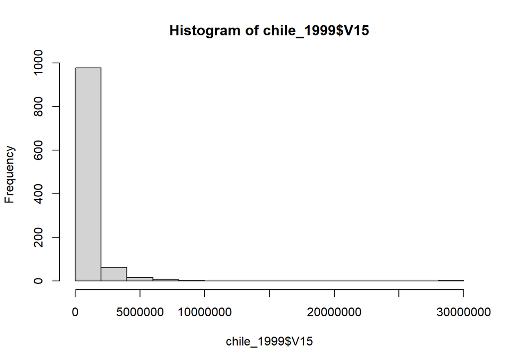

```
##     Min.  1st Qu.   Median     Mean  3rd Qu.     Max.     NA's
##    50000   400000   700000  1116332  1000000 30000000      437
```

```r
summary(chile_1999$V15) # recomiendo filtrar `<= $ 100.000 y >= $10.000.000`
hist(chile_1999$V15)
```

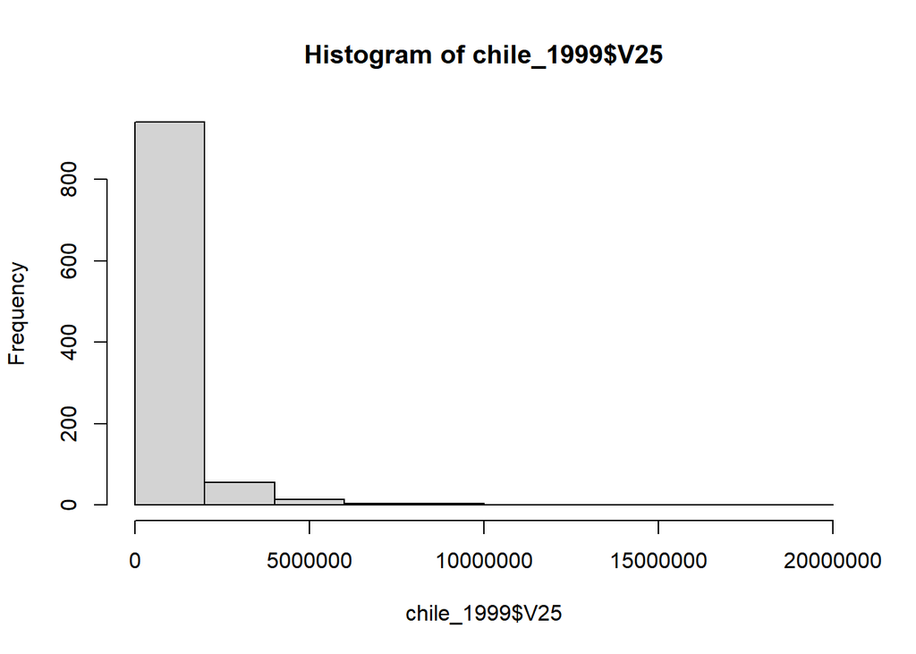

```
##     Min.  1st Qu.   Median     Mean  3rd Qu.     Max.     NA's
##    80000   500000  1000000  1213935  1500000 20000000      484
```

```r
summary(chile_1999$V25) # recomiendo filtrar `<= $ 100.000 y >= $10.000.000`
hist(chile_1999$V25)
```

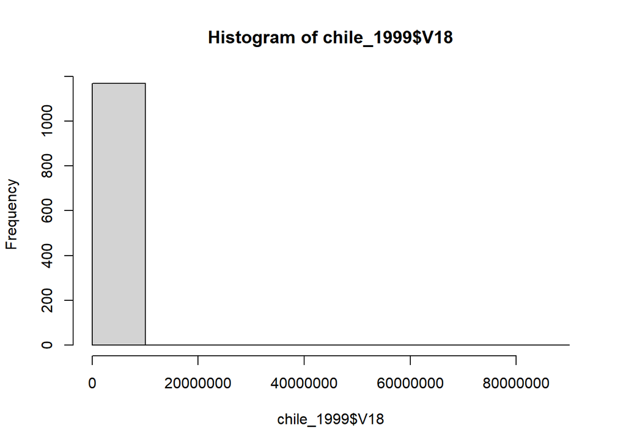

```
##     Min.  1st Qu.   Median     Mean  3rd Qu.     Max.     NA's
##    30000   100000   150000   251367   200000 90000000      335
```

```r
summary(chile_1999$V18) # recomiendo filtrar `<= $ 50.000 y >= $10.000.000`
hist(chile_1999$V18)
```

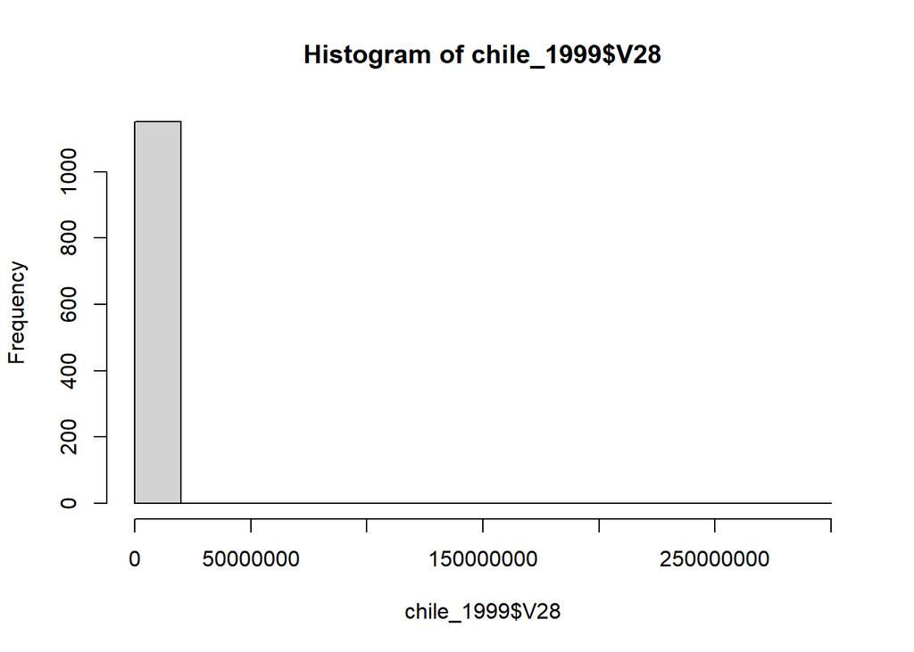

```
##      Min.   1st Qu.    Median      Mean   3rd Qu.      Max.      NA's
##     90000    200000    250000    550904    300000 300000000       352
```

```r
summary(chile_1999$V28) # recomiendo filtrar `<= $ 50.000 y >= $10.000.000`
hist(chile_1999$V28)
```

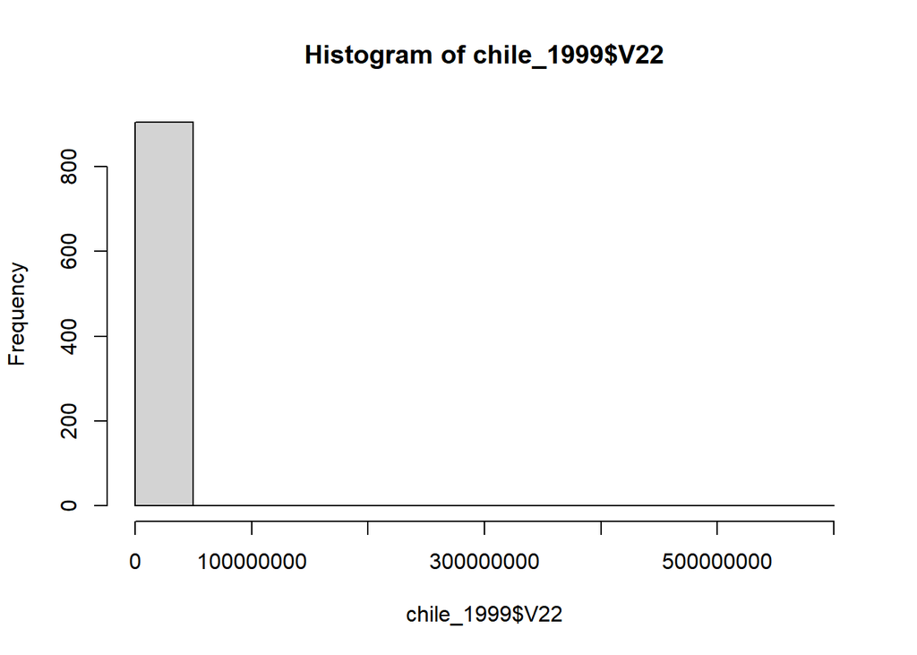

```
##      Min.   1st Qu.    Median      Mean   3rd Qu.      Max.      NA's
##     72000   1000000   2000000   4222549   4000000 600000000       596
```

```r
summary(chile_1999$V22)  # recomiendo filtrar `<= $ 100.000 y >= $100.000.000`
hist(chile_1999$V22)
```